# Module 51

#### Contrast SVE:

Signed variance explained (SVE) provides an indication of how similar a set of fold changes are to a gene module’s weight vector. An SVE value of 0.3, for example, indicates that 30% of the variance explained by the entire module set is accounted for by the module in question. Shown here are the SVE values for this module across a compendium of fold changes (contrasts). Extreme SVE values (e.g., > 0.05) indicate that those contrasts specifically induce (orange dots) or specifically repress (blue dots) this module. Examining the experimental conditions being compared in such contrasts (see tables below the figure) may provide insight into the gene module’s function.

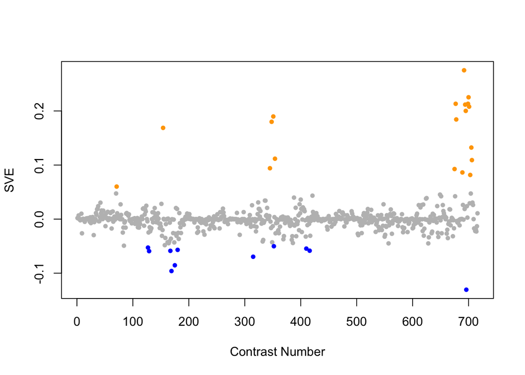

Positive SVE Contrasts:

|  | Contrast.Num | SVE | GEO.GSE | Cond.1 | Cond.2 | Mutation |
| --- | --- | --- | --- | --- | --- | --- |
| GSE11055.s5t7.vs.s2t7 | 692 | 0.28 | GSE11055 | L1 larvae starved for 12 hr after hatching and then fed for 3 hr | L1 larvae 15 hr after hatching in the absence of food |  |
| GSE11055.s1t4.vs.s3t4 | 700 | 0.23 | GSE11055 | L1 larvae 3 hr after hatching in the presence of food | L1 larvae 3 hr after hatching in the absence of food in the alternative starvation buffer M9 |  |
| GSE11055.s1t4.vs.s2t4 | 699 | 0.21 | GSE11055 | L1 larvae 3 hr after hatching in the presence of food | L1 larvae 3 hr after hatching in the absence of food |  |
| GSE13258.s2t1.vs.s0t1 | 677 | 0.21 | GSE13258 | rde-4 mutant, biological rep 1 | wild-type, biological rep 1 | rde-4 |
| GSE11055.s5t7.vs.s4t7 | 694 | 0.21 | GSE11055 | L1 larvae starved for 12 hr after hatching and then fed for 3 hr | L1 larvae fed for 12 hr after hatching and then starved for 3 hr |  |
| GSE11055.s1t5.vs.s2t5 | 701 | 0.21 | GSE11055 | L1 larvae 6 hr after hatching in the presence of food | L1 larvae 6 hr after hatching in the absence of food |  |
| GSE11055.s1t7.vs.s4t7 | 695 | 0.20 | GSE11055 | L1-L2 larvae 15 hr after hatching in the presence of food | L1 larvae fed for 12 hr after hatching and then starved for 3 hr |  |
| GSE38997.s3t4.vs.s3t1 | 351 | 0.19 | GSE38997 | experiment 1 UVC- and EtBr-exposed samples at 51 h 1eu51 | experiment 4 UVC- and EtBr-exposed samples at 3 h 4eu3 |  |
| GSE13258.s1t1.vs.s0t1 | 678 | 0.18 | GSE13258 | zfp-1 mutant, biological rep 1 | wild-type, biological rep 1 | zfp-1 |
| GSE38997.s2t4.vs.s2t1 | 348 | 0.18 | GSE38997 | experiment 1 EtBr-exposed samples at 51 h 1e51 | experiment 4 EtBr-exposed samples at 3 h 4e3 |  |
| GSE47778.s4t1.vs.s2t1 | 154 | 0.17 | GSE47778 | daf-2;daf-16; replicate 1 | daf-2; replicate 1 | daf-2;daf-16 vs. daf-2 |
| GSE11055.s1t4.vs.s1t1 | 705 | 0.13 | GSE11055 | L1 larvae 3 hr after hatching in the presence of food | embryo 2 hr before hatching |  |
| GSE38997.s4t4.vs.s4t1 | 354 | 0.11 | GSE38997 | experiment 1 UVC-exposed samples at 51 h 1u51 | experiment 4 UVC-exposed samples at 3 h 4u3 |  |
| GSE11055.s1t5.vs.s1t1 | 706 | 0.11 | GSE11055 | L1 larvae 6 hr after hatching in the presence of food | embryo 2 hr before hatching |  |
| GSE38997.s1t4.vs.s1t1 | 345 | 0.09 | GSE38997 | experiment 1 control samples at 51 h 1c51 | experiment 4 control samples at 3 h 4c3 |  |
| GSE13258.s4t1.vs.s0t1 | 675 | 0.09 | GSE13258 | alg-1 mutant, biological rep 1 | wild-type, biological rep 1 | alg-1 |
| GSE11055.s1t3.vs.s2t3 | 689 | 0.09 | GSE11055 | L1 larvae 1 hr after hatching in the presence of food | L1 larvae 1 hr after hatching in the absence of food |  |
| GSE11055.s1t3.vs.s1t1 | 703 | 0.08 | GSE11055 | L1 larvae 1 hr after hatching in the presence of food | embryo 2 hr before hatching |  |
| GSE8462.s2t2.vs.s2t1 | 71 | 0.06 | GSE8462 | 24 hr Reference, biological rep 1 | 0 hr Reference, biological rep 1 |  |

Negative SVE Contrasts:

|  | Contrast.Num | SVE | GEO.GSE | Cond.1 | Cond.2 | Mutation |
| --- | --- | --- | --- | --- | --- | --- |
| GSE11055.s1t7.vs.s5t7 | 696 | -0.13 | GSE11055 | L1-L2 larvae 15 hr after hatching in the presence of food | L1 larvae starved for 12 hr after hatching and then fed for 3 hr |  |
| GSE47778.s5t3.vs.s3t3 | 169 | -0.10 | GSE47778 | xpa-1 10mJ/cm2; replicate 1 | daf-16; UV; replicate 1 | xpa-1 vs. daf-16 |
| GSE47778.s5t3.vs.s1t3 | 175 | -0.09 | GSE47778 | xpa-1 10mJ/cm2; replicate 1 | N2; UV; replicate 1 | xpa-1 |
| GSE40127.s1t1.vs.s0t1 | 315 | -0.07 | GSE40127 | 1E_MK_Celegans_E_1 | 2c_MK_Celegans_Control_2 | gei-8 |
| GSE54011.s4t1.vs.s0t1 | 129 | -0.06 | GSE54011 | Ce 0.4 mM Se | Ce 0 mM Se |  |
| GSE47778.s4t3.vs.s3t3 | 167 | -0.06 | GSE47778 | daf-2;daf-16; UV; replicate 1 | daf-16; UV; replicate 1 | daf-2;daf-16 vs. daf-16 |
| GSE29951.s0t2.vs.s0t1 | 416 | -0.06 | GSE29951 | C.elegans wild type raised in the presence of Cd, rep1 | C.elegans wild type raised in the absence of Cd, rep1 |  |
| GSE47778.s4t2.vs.s4t1 | 180 | -0.06 | GSE47778 | daf-2;daf-16; starvation; replicate 1 | daf-2;daf-16; replicate 1 |  |
| GSE30505.s3t2.vs.s3t1 | 410 | -0.05 | GSE30505 | Day 8 glp-1 E.V. #1 | L3 glp-1 E.V. #1 |  |
| GSE54011.s2t1.vs.s0t1 | 127 | -0.05 | GSE54011 | Ce 0.1 mM Se | Ce 0 mM Se |  |
| GSE38997.s3t2.vs.s3t1 | 352 | -0.05 | GSE38997 | experiment 4 UVC- and EtBr-exposed samples at 24 h 4eu24 | experiment 4 UVC- and EtBr-exposed samples at 3 h 4eu3 |  |

$~$

#### Contrast SVE, Up-Regulated Genes Only:

Calculating SVE for up-regulated and down-regulated genes separately may be more informative in many cases than projecting the up- and down- gene sets together. This is due to the fact that the weight distribution of many modules is highly skewed, indicating that only one of the hemi-modules may be biologically meaningful (i.e., a set of genes are strongly correlated by only a few genes (or none) are strongly anti-correlated to that set.)

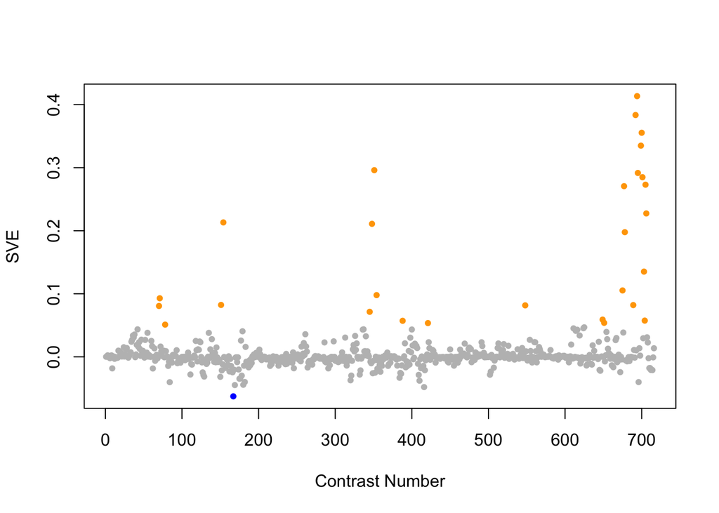

Positive SVE Contrasts:

|  | Contrast.Num | SVE | GEO.GSE | Cond.1 | Cond.2 | Mutation |
| --- | --- | --- | --- | --- | --- | --- |
| GSE11055.s5t7.vs.s4t7 | 694 | 0.41 | GSE11055 | L1 larvae starved for 12 hr after hatching and then fed for 3 hr | L1 larvae fed for 12 hr after hatching and then starved for 3 hr |  |
| GSE11055.s5t7.vs.s2t7 | 692 | 0.38 | GSE11055 | L1 larvae starved for 12 hr after hatching and then fed for 3 hr | L1 larvae 15 hr after hatching in the absence of food |  |
| GSE11055.s1t4.vs.s3t4 | 700 | 0.36 | GSE11055 | L1 larvae 3 hr after hatching in the presence of food | L1 larvae 3 hr after hatching in the absence of food in the alternative starvation buffer M9 |  |
| GSE11055.s1t4.vs.s2t4 | 699 | 0.33 | GSE11055 | L1 larvae 3 hr after hatching in the presence of food | L1 larvae 3 hr after hatching in the absence of food |  |
| GSE38997.s3t4.vs.s3t1 | 351 | 0.30 | GSE38997 | experiment 1 UVC- and EtBr-exposed samples at 51 h 1eu51 | experiment 4 UVC- and EtBr-exposed samples at 3 h 4eu3 |  |
| GSE11055.s1t7.vs.s4t7 | 695 | 0.29 | GSE11055 | L1-L2 larvae 15 hr after hatching in the presence of food | L1 larvae fed for 12 hr after hatching and then starved for 3 hr |  |
| GSE11055.s1t5.vs.s2t5 | 701 | 0.28 | GSE11055 | L1 larvae 6 hr after hatching in the presence of food | L1 larvae 6 hr after hatching in the absence of food |  |
| GSE11055.s1t4.vs.s1t1 | 705 | 0.27 | GSE11055 | L1 larvae 3 hr after hatching in the presence of food | embryo 2 hr before hatching |  |
| GSE13258.s2t1.vs.s0t1 | 677 | 0.27 | GSE13258 | rde-4 mutant, biological rep 1 | wild-type, biological rep 1 | rde-4 |
| GSE11055.s1t5.vs.s1t1 | 706 | 0.23 | GSE11055 | L1 larvae 6 hr after hatching in the presence of food | embryo 2 hr before hatching |  |
| GSE47778.s4t1.vs.s2t1 | 154 | 0.21 | GSE47778 | daf-2;daf-16; replicate 1 | daf-2; replicate 1 | daf-2;daf-16 vs. daf-2 |
| GSE38997.s2t4.vs.s2t1 | 348 | 0.21 | GSE38997 | experiment 1 EtBr-exposed samples at 51 h 1e51 | experiment 4 EtBr-exposed samples at 3 h 4e3 |  |
| GSE13258.s1t1.vs.s0t1 | 678 | 0.20 | GSE13258 | zfp-1 mutant, biological rep 1 | wild-type, biological rep 1 | zfp-1 |
| GSE11055.s1t3.vs.s1t1 | 703 | 0.14 | GSE11055 | L1 larvae 1 hr after hatching in the presence of food | embryo 2 hr before hatching |  |
| GSE13258.s4t1.vs.s0t1 | 675 | 0.11 | GSE13258 | alg-1 mutant, biological rep 1 | wild-type, biological rep 1 | alg-1 |
| GSE38997.s4t4.vs.s4t1 | 354 | 0.10 | GSE38997 | experiment 1 UVC-exposed samples at 51 h 1u51 | experiment 4 UVC-exposed samples at 3 h 4u3 |  |
| GSE8462.s2t2.vs.s2t1 | 71 | 0.09 | GSE8462 | 24 hr Reference, biological rep 1 | 0 hr Reference, biological rep 1 |  |
| GSE47778.s4t1.vs.s3t1 | 151 | 0.08 | GSE47778 | daf-2;daf-16; replicate 1 | daf-16; replicate 1 | daf-2;daf-16 vs. daf-16 |
| GSE11055.s1t3.vs.s2t3 | 689 | 0.08 | GSE11055 | L1 larvae 1 hr after hatching in the presence of food | L1 larvae 1 hr after hatching in the absence of food |  |
| GSE2180.s3t3.vs.s2t3 | 548 | 0.08 | GSE2180 | p41-2 | ms41-1 |  |
| GSE8462.s1t2.vs.s1t1 | 70 | 0.08 | GSE8462 | 24 hr muscle, biological rep 1 | 0 hr muscle, biological rep 1 |  |
| GSE38997.s1t4.vs.s1t1 | 345 | 0.07 | GSE38997 | experiment 1 control samples at 51 h 1c51 | experiment 4 control samples at 3 h 4c3 |  |
| GSE16405.s2t1.vs.s1t1 | 649 | 0.06 | GSE16405 | nth-1_1 | N2_1 | nth-1 |
| GSE11055.s1t6.vs.s1t1 | 704 | 0.06 | GSE11055 | L1 larvae 12 hr after hatching in the presence of food | embryo 2 hr before hatching |  |
| GSE32949.s1t1.vs.s0t1 | 388 | 0.06 | GSE32949 | C. elegans exposed to space condition, technical rep1 | C. elegans ground control, technical rep1 |  |
| GSE16405.s4t1.vs.s1t1 | 651 | 0.05 | GSE16405 | xpa-1_1 | N2_1 | xpa-1 |
| GSE28494.s1t2.vs.s0t2 | 421 | 0.05 | GSE28494 | lin-54(n3423) dissected germline 1 | wild-type N2 dissected germline 1 | lin-54 |
| GSE8004.s2t2.vs.s1t2 | 78 | 0.05 | GSE8004 | Larval Reference, biological rep 1 of set 1 | Larval A-class, biological rep 1 of set 3 |  |

Negative SVE Contrasts:

[output not shown]

$~$

#### Contrast SVE, Down-Regulated Genes Only:

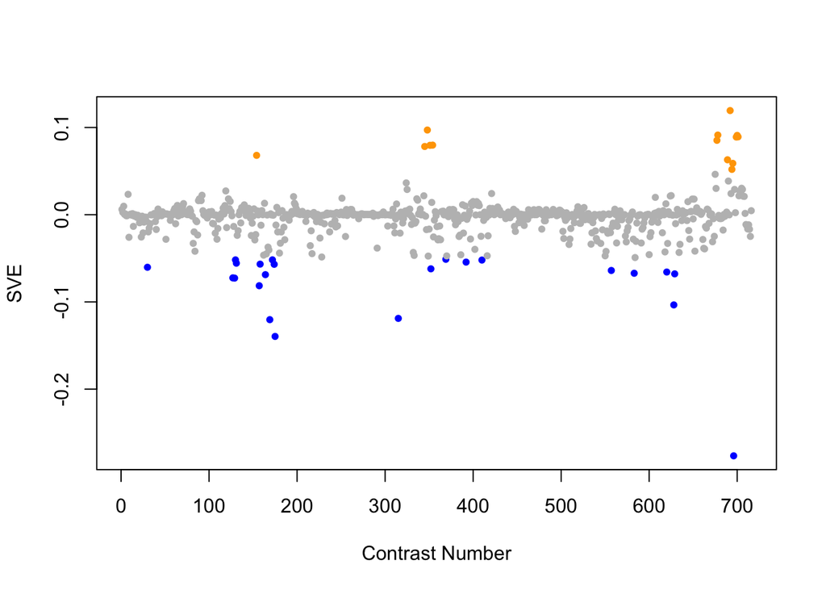

Positive SVE Contrasts:

|  | Contrast.Num | SVE | GEO.GSE | Cond.1 | Cond.2 | Mutation |
| --- | --- | --- | --- | --- | --- | --- |
| GSE11055.s5t7.vs.s2t7 | 692 | 0.12 | GSE11055 | L1 larvae starved for 12 hr after hatching and then fed for 3 hr | L1 larvae 15 hr after hatching in the absence of food |  |
| GSE38997.s2t4.vs.s2t1 | 348 | 0.10 | GSE38997 | experiment 1 EtBr-exposed samples at 51 h 1e51 | experiment 4 EtBr-exposed samples at 3 h 4e3 |  |
| GSE13258.s1t1.vs.s0t1 | 678 | 0.09 | GSE13258 | zfp-1 mutant, biological rep 1 | wild-type, biological rep 1 | zfp-1 |
| GSE11055.s1t4.vs.s3t4 | 700 | 0.09 | GSE11055 | L1 larvae 3 hr after hatching in the presence of food | L1 larvae 3 hr after hatching in the absence of food in the alternative starvation buffer M9 |  |
| GSE11055.s1t5.vs.s2t5 | 701 | 0.09 | GSE11055 | L1 larvae 6 hr after hatching in the presence of food | L1 larvae 6 hr after hatching in the absence of food |  |
| GSE11055.s1t4.vs.s2t4 | 699 | 0.09 | GSE11055 | L1 larvae 3 hr after hatching in the presence of food | L1 larvae 3 hr after hatching in the absence of food |  |
| GSE13258.s2t1.vs.s0t1 | 677 | 0.09 | GSE13258 | rde-4 mutant, biological rep 1 | wild-type, biological rep 1 | rde-4 |
| GSE38997.s4t4.vs.s4t1 | 354 | 0.08 | GSE38997 | experiment 1 UVC-exposed samples at 51 h 1u51 | experiment 4 UVC-exposed samples at 3 h 4u3 |  |
| GSE38997.s3t4.vs.s3t1 | 351 | 0.08 | GSE38997 | experiment 1 UVC- and EtBr-exposed samples at 51 h 1eu51 | experiment 4 UVC- and EtBr-exposed samples at 3 h 4eu3 |  |
| GSE38997.s1t4.vs.s1t1 | 345 | 0.08 | GSE38997 | experiment 1 control samples at 51 h 1c51 | experiment 4 control samples at 3 h 4c3 |  |
| GSE47778.s4t1.vs.s2t1 | 154 | 0.07 | GSE47778 | daf-2;daf-16; replicate 1 | daf-2; replicate 1 | daf-2;daf-16 vs. daf-2 |
| GSE11055.s1t3.vs.s2t3 | 689 | 0.06 | GSE11055 | L1 larvae 1 hr after hatching in the presence of food | L1 larvae 1 hr after hatching in the absence of food |  |
| GSE11055.s1t7.vs.s4t7 | 695 | 0.06 | GSE11055 | L1-L2 larvae 15 hr after hatching in the presence of food | L1 larvae fed for 12 hr after hatching and then starved for 3 hr |  |
| GSE11055.s5t7.vs.s4t7 | 694 | 0.05 | GSE11055 | L1 larvae starved for 12 hr after hatching and then fed for 3 hr | L1 larvae fed for 12 hr after hatching and then starved for 3 hr |  |

Negative SVE Contrasts:

|  | Contrast.Num | SVE | GEO.GSE | Cond.1 | Cond.2 | Mutation |
| --- | --- | --- | --- | --- | --- | --- |
| GSE11055.s1t7.vs.s5t7 | 696 | -0.28 | GSE11055 | L1-L2 larvae 15 hr after hatching in the presence of food | L1 larvae starved for 12 hr after hatching and then fed for 3 hr |  |
| GSE47778.s5t3.vs.s1t3 | 175 | -0.14 | GSE47778 | xpa-1 10mJ/cm2; replicate 1 | N2; UV; replicate 1 | xpa-1 |
| GSE47778.s5t3.vs.s3t3 | 169 | -0.12 | GSE47778 | xpa-1 10mJ/cm2; replicate 1 | daf-16; UV; replicate 1 | xpa-1 vs. daf-16 |
| GSE40127.s1t1.vs.s0t1 | 315 | -0.12 | GSE40127 | 1E_MK_Celegans_E_1 | 2c_MK_Celegans_Control_2 | gei-8 |
| GSE19310A.s1t1.vs.s0t1 | 628 | -0.10 | GSE19310 | osm-11(n1604) at iso, rep1 | N2 at iso, rep1 | osm-11 |
| GSE47778.s1t1.vs.s4t1 | 157 | -0.08 | GSE47778 | N2; replicate 1 | daf-2;daf-16; replicate 1 | daf-2;daf-16 |
| GSE54011.s4t1.vs.s0t1 | 129 | -0.07 | GSE54011 | Ce 0.4 mM Se | Ce 0 mM Se |  |
| GSE54011.s2t1.vs.s0t1 | 127 | -0.07 | GSE54011 | Ce 0.1 mM Se | Ce 0 mM Se |  |
| GSE47778.s1t2.vs.s2t2 | 164 | -0.07 | GSE47778 | N2; starvation; replicate 1 | daf-2; starvation; replicate 1 | daf-2 |
| GSE19310A.s2t1.vs.s0t1 | 629 | -0.07 | GSE19310 | osm-7(n1515) at iso, rep1 | N2 at iso, rep1 | osm-7 |
| GSE2180.s2t3.vs.s2t1 | 583 | -0.07 | GSE2180 | ms41-1 | ms0-1 |  |
| GSE21376.s1t1.vs.s0t1 | 620 | -0.07 | GSE21376 | L1 larvae treated with let-418(RNAi), replicate 1 | L1 larvae treated with gfp(RNAi), replicate 1 | let-418 |
| GSE2180.s2t5.vs.s1t5 | 557 | -0.06 | GSE2180 | ms66-3 | 66-4 | mex-3(zu155);skn-1(RNAi) |
| GSE38997.s3t2.vs.s3t1 | 352 | -0.06 | GSE38997 | experiment 4 UVC- and EtBr-exposed samples at 24 h 4eu24 | experiment 4 UVC- and EtBr-exposed samples at 3 h 4eu3 |  |
| GSE9665.s9t2.vs.s0t2 | 30 | -0.06 | GSE9665 | mex-3 scrt-1 186 A | mex-3 186 A | scrt-1 |
| GSE47778.s5t3.vs.s4t3 | 174 | -0.06 | GSE47778 | xpa-1 10mJ/cm2; replicate 1 | daf-2;daf-16; UV; replicate 1 | xpa-1 vs. daf-2;daf-16 |
| GSE47778.s5t1.vs.s4t1 | 158 | -0.06 | GSE47778 | xpa-1 0mJ/cm2; replicate 1 | daf-2;daf-16; replicate 1 | xpa-1 vs. daf-2;daf-16 |
| GSE52064.s2t1.vs.s3t1 | 131 | -0.06 | GSE52064 | mes-4_1 | lin-54_1 | mes-4 vs. lin-54 |
| GSE32339.s1t2.vs.s0t2 | 392 | -0.05 | GSE32339 | Adult Mutant, biological rep1 | Adult Wild-type, biological rep1 | nep-1 |
| GSE30505.s3t2.vs.s3t1 | 410 | -0.05 | GSE30505 | Day 8 glp-1 E.V. #1 | L3 glp-1 E.V. #1 |  |
| GSE52064.s4t1.vs.s3t1 | 130 | -0.05 | GSE52064 | lin-54;mes-4_1 | lin-54_1 | mes-4 |
| GSE47778.s5t3.vs.s2t3 | 172 | -0.05 | GSE47778 | xpa-1 10mJ/cm2; replicate 1 | daf-2; UV; replicate 1 | xpa-1 vs. daf-2 |
| GSE35360B.s1t1.vs.s0t1 | 369 | -0.05 | GSE35360 | HF 3d_0.2_rep1 | HF 3d control_rep1 |  |

$~$

$~$

#### GO Term Enrichment:

This analysis tests each hemi-module for enrichment of specific GO terms. Only gene-level annotations (e.g., as would be found on the gene’s page in Wormbase) are tested - the hierarchical structure of the GO ontology is not taken into account.

*Note: At least the top two most enriched terms from each GO domain (BP/MF/CC) are shown, even when not statistically significant.*

##### Enriched GO terms: Hemi-module A

| ID | GO.Term | GO Domain | Raw p-value | Adj p-value |
| --- | --- | --- | --- | --- |
| [GO_0006364](http://amigo.geneontology.org/amigo/term/GO:0006364) | rRNA processing | BP | 2.82e-53 | 1.03e-49 |
| [GO_0042254](http://amigo.geneontology.org/amigo/term/GO:0042254) | ribosome biogenesis | BP | 1.51e-34 | 2.74e-31 |
| [GO_0006412](http://amigo.geneontology.org/amigo/term/GO:0006412) | translation | BP | 3.92e-32 | 4.75e-29 |
| [GO_0042273](http://amigo.geneontology.org/amigo/term/GO:0042273) | ribosomal large subunit biogenesis | BP | 1.09e-15 | 9.90e-13 |
| [GO_0000462](http://amigo.geneontology.org/amigo/term/GO:0000462) | maturation of SSU-rRNA from tricistronic rRNA transcript (SSU-rRNA, 5.8S rRNA, LSU-rRNA) | BP | 3.18e-15 | 2.32e-12 |
| [GO_0008033](http://amigo.geneontology.org/amigo/term/GO:0008033) | tRNA processing | BP | 4.97e-13 | 3.02e-10 |
| [GO_0006413](http://amigo.geneontology.org/amigo/term/GO:0006413) | translational initiation | BP | 1.75e-12 | 9.10e-10 |
| [GO_0032259](http://amigo.geneontology.org/amigo/term/GO:0032259) | methylation | BP | 8.12e-11 | 3.70e-08 |
| [GO_0032543](http://amigo.geneontology.org/amigo/term/GO:0032543) | mitochondrial translation | BP | 1.02e-10 | 4.15e-08 |
| [GO_0002183](http://amigo.geneontology.org/amigo/term/GO:0002183) | cytoplasmic translational initiation | BP | 4.07e-10 | 1.48e-07 |
| [GO_0000463](http://amigo.geneontology.org/amigo/term/GO:0000463) | maturation of LSU-rRNA from tricistronic rRNA transcript (SSU-rRNA, 5.8S rRNA, LSU-rRNA) | BP | 1.45e-09 | 4.40e-07 |
| [GO_0001522](http://amigo.geneontology.org/amigo/term/GO:0001522) | pseudouridine synthesis | BP | 1.45e-09 | 4.40e-07 |
| [GO_0006351](http://amigo.geneontology.org/amigo/term/GO:0006351) | transcription, DNA-templated | BP | 1.40e-08 | 3.91e-06 |
| [GO_0000466](http://amigo.geneontology.org/amigo/term/GO:0000466) | maturation of 5.8S rRNA from tricistronic rRNA transcript (SSU-rRNA, 5.8S rRNA, LSU-rRNA) | BP | 1.70e-08 | 4.42e-06 |
| [GO_0001732](http://amigo.geneontology.org/amigo/term/GO:0001732) | formation of cytoplasmic translation initiation complex | BP | 1.93e-08 | 4.68e-06 |
| [GO_0006400](http://amigo.geneontology.org/amigo/term/GO:0006400) | tRNA modification | BP | 8.98e-08 | 2.04e-05 |
| [GO_0006383](http://amigo.geneontology.org/amigo/term/GO:0006383) | transcription by RNA polymerase III | BP | 1.19e-07 | 2.56e-05 |
| [GO_0006360](http://amigo.geneontology.org/amigo/term/GO:0006360) | transcription by RNA polymerase I | BP | 3.77e-07 | 7.62e-05 |
| [GO_0007186](http://amigo.geneontology.org/amigo/term/GO:0007186) | G protein-coupled receptor signaling pathway | BP | 5.54e-07 | 1.06e-04 |
| [GO_0016075](http://amigo.geneontology.org/amigo/term/GO:0016075) | rRNA catabolic process | BP | 6.12e-07 | 1.11e-04 |
| [GO_0031167](http://amigo.geneontology.org/amigo/term/GO:0031167) | rRNA methylation | BP | 8.87e-07 | 1.54e-04 |
| [GO_0000027](http://amigo.geneontology.org/amigo/term/GO:0000027) | ribosomal large subunit assembly | BP | 1.07e-06 | 1.78e-04 |
| [GO_0002098](http://amigo.geneontology.org/amigo/term/GO:0002098) | tRNA wobble uridine modification | BP | 1.17e-06 | 1.85e-04 |
| [GO_0006457](http://amigo.geneontology.org/amigo/term/GO:0006457) | protein folding | BP | 2.14e-06 | 3.24e-04 |
| [GO_0034427](http://amigo.geneontology.org/amigo/term/GO:0034427) | nuclear-transcribed mRNA catabolic process, exonucleolytic, 3’-5’ | BP | 2.99e-06 | 4.04e-04 |
| [GO_0034475](http://amigo.geneontology.org/amigo/term/GO:0034475) | U4 snRNA 3’-end processing | BP | 2.99e-06 | 4.04e-04 |
| [GO_0070125](http://amigo.geneontology.org/amigo/term/GO:0070125) | mitochondrial translational elongation | BP | 2.99e-06 | 4.04e-04 |
| [GO_0009451](http://amigo.geneontology.org/amigo/term/GO:0009451) | RNA modification | BP | 3.81e-06 | 4.96e-04 |
| [GO_0006418](http://amigo.geneontology.org/amigo/term/GO:0006418) | tRNA aminoacylation for protein translation | BP | 5.38e-06 | 6.76e-04 |
| [GO_0006355](http://amigo.geneontology.org/amigo/term/GO:0006355) | regulation of transcription, DNA-templated | BP | 7.90e-06 | 9.59e-04 |

[output cut: 125 more lines]

##### Enriched GO terms: Hemi-module B

| ID | GO.Term | GO Domain | Raw p-value | Adj p-value |
| --- | --- | --- | --- | --- |
| [GO_0097352](http://amigo.geneontology.org/amigo/term/GO:0097352) | autophagosome maturation | BP | 2.89e-05 | 7.89e-02 |
| [GO_0006995](http://amigo.geneontology.org/amigo/term/GO:0006995) | cellular response to nitrogen starvation | BP | 4.33e-05 | 7.89e-02 |
| [GO_0004512](http://amigo.geneontology.org/amigo/term/GO:0004512) | inositol-3-phosphate synthase activity | MF | 1.75e-03 | 7.74e-01 |
| [GO_0031625](http://amigo.geneontology.org/amigo/term/GO:0031625) | ubiquitin protein ligase binding | MF | 2.07e-03 | 7.74e-01 |
| [GO_0000421](http://amigo.geneontology.org/amigo/term/GO:0000421) | autophagosome membrane | CC | 4.33e-05 | 4.02e-02 |
| [GO_0005776](http://amigo.geneontology.org/amigo/term/GO:0005776) | autophagosome | CC | 2.24e-04 | 1.04e-01 |

$~$

$~$

#### Tissue Enrichment:

This analysis tests each hemi-module for enrichment of genes associated with anatomy terms. Negative enrichment scores indicate fewer hemi-module genes than expected by random chance were associated with the anatomy term in question.

##### Enriched tissues: Hemi-module A

| ID | Anatomy.Term | Definition | Raw p-value | Adj p-value |
| --- | --- | --- | --- | --- |
| [WBbt_0005813](https://wormbase.org/species/all/anatomy_term/WBbt:0005813) | body wall musculature | Longitudinal bands of muscle cells surrounding animal body, with one band running in each quadrant of the body, regulated contraction and relaxation of these muscles cause locomotion. | 1.04e-06 | 2.49e-03 |
| [WBbt_0003681](https://wormbase.org/species/all/anatomy_term/WBbt:0003681) | pharynx | the feeding organ, a neuro-muscular pump in the head of the animal, used to ingest food, bacteria suspended in liquid, filter them out, grind them up and transport posteriorly into the instestine. | 2.04e-06 | 2.49e-03 |
| [WBbt_0004017](https://wormbase.org/species/all/anatomy_term/WBbt:0004017) | Cell | a cellular object that consists of subcellular components, expresses genes or functions. | 1.12e-04 | 9.07e-02 |

##### Enriched tissues: Hemi-module B

No significant annotations.

$~$

$~$

#### HOMER promoter motif enrichment:

This analysis tests each hemi-module for enrichment of 108 known *C. elegans* transcription factor binding site motifs (see [108 CE motifs](https://katiepod.github.io//all.worm.motifs.html)) using the HOMER (Hypergeometric Optimization of Motif EnRichment) software (see [PMID:20513432](https://pubmed.ncbi.nlm.nih.gov/20513432)). HOMER was run using default parameters on sequences 1 kb upstream of the transcription start site.

##### Motif enrichment: Hemi-module A

Total target sequences = 353  
Total background sequences = 37188  
* - possible false positive

Rank

Motif

P-value

log P-pvalue

% of Targets

% of Background

STD(Bg STD)

Best Match/Details

Motif File

1

[figure not shown]

1e-15

-3.489e+01

55.52%

34.47%

313.1bp (393.2bp)

pqm-1/MA1703.1/Jaspar(0.717)  
[More Information](https://katiepod.github.io/HomerResults/m51_a_hemi_genes.txt.out.1kb/homerResults/motif1.info.html) | [Similar Motifs Found](https://katiepod.github.io/HomerResults/m51_a_hemi_genes.txt.out.1kb/homerResults/motif1.similar.html)

[motif file (matrix)](https://katiepod.github.io/HomerResults/m51_a_hemi_genes.txt.out.1kb/homerResults/motif1.motif)

2

[figure not shown]

1e-14

-3.430e+01

11.05%

2.26%

267.2bp (370.8bp)

PHA-4(Forkhead)/cElegans-Embryos-PHA4-ChIP-Seq(modEncode)/Homer(0.669)  
[More Information](https://katiepod.github.io/HomerResults/m51_a_hemi_genes.txt.out.1kb/homerResults/motif2.info.html) | [Similar Motifs Found](https://katiepod.github.io/HomerResults/m51_a_hemi_genes.txt.out.1kb/homerResults/motif2.similar.html)

[motif file (matrix)](https://katiepod.github.io/HomerResults/m51_a_hemi_genes.txt.out.1kb/homerResults/motif2.motif)

3

[figure not shown]

1e-14

-3.424e+01

7.37%

0.90%

253.0bp (345.3bp)

che-1/MA0260.1/Jaspar(0.557)  
[More Information](https://katiepod.github.io/HomerResults/m51_a_hemi_genes.txt.out.1kb/homerResults/motif3.info.html) | [Similar Motifs Found](https://katiepod.github.io/HomerResults/m51_a_hemi_genes.txt.out.1kb/homerResults/motif3.similar.html)

[motif file (matrix)](https://katiepod.github.io/HomerResults/m51_a_hemi_genes.txt.out.1kb/homerResults/motif3.motif)

4

[figure not shown]

1e-13

-3.031e+01

31.16%

15.26%

253.4bp (366.5bp)

DPL-1(E2F)/cElegans-Adult-ChIP-Seq(modEncode)/Homer(0.729)  
[More Information](https://katiepod.github.io/HomerResults/m51_a_hemi_genes.txt.out.1kb/homerResults/motif4.info.html) | [Similar Motifs Found](https://katiepod.github.io/HomerResults/m51_a_hemi_genes.txt.out.1kb/homerResults/motif4.similar.html)

[motif file (matrix)](https://katiepod.github.io/HomerResults/m51_a_hemi_genes.txt.out.1kb/homerResults/motif4.motif)

5

[figure not shown]

1e-12

-2.925e+01

4.82%

0.38%

253.6bp (414.3bp)

efl-1/MA0541.1/Jaspar(0.771)  
[More Information](https://katiepod.github.io/HomerResults/m51_a_hemi_genes.txt.out.1kb/homerResults/motif5.info.html) | [Similar Motifs Found](https://katiepod.github.io/HomerResults/m51_a_hemi_genes.txt.out.1kb/homerResults/motif5.similar.html)

[motif file (matrix)](https://katiepod.github.io/HomerResults/m51_a_hemi_genes.txt.out.1kb/homerResults/motif5.motif)

6

[figure not shown]

1e-12

-2.886e+01

5.10%

0.46%

297.7bp (391.4bp)

blmp-1/MA0537.1/Jaspar(0.565)  
[More Information](https://katiepod.github.io/HomerResults/m51_a_hemi_genes.txt.out.1kb/homerResults/motif6.info.html) | [Similar Motifs Found](https://katiepod.github.io/HomerResults/m51_a_hemi_genes.txt.out.1kb/homerResults/motif6.similar.html)

[motif file (matrix)](https://katiepod.github.io/HomerResults/m51_a_hemi_genes.txt.out.1kb/homerResults/motif6.motif)

7

[figure not shown]

1e-12

-2.886e+01

5.38%

0.53%

261.3bp (340.2bp)

PL0012.1_hlh-2::hlh-8/Jaspar(0.585)  
[More Information](https://katiepod.github.io/HomerResults/m51_a_hemi_genes.txt.out.1kb/homerResults/motif7.info.html) | [Similar Motifs Found](https://katiepod.github.io/HomerResults/m51_a_hemi_genes.txt.out.1kb/homerResults/motif7.similar.html)

[motif file (matrix)](https://katiepod.github.io/HomerResults/m51_a_hemi_genes.txt.out.1kb/homerResults/motif7.motif)

8

[figure not shown]

1e-12

-2.802e+01

12.75%

3.63%

269.2bp (355.2bp)

POL008.1_DCE_S_I/Jaspar(0.623)  
[More Information](https://katiepod.github.io/HomerResults/m51_a_hemi_genes.txt.out.1kb/homerResults/motif8.info.html) | [Similar Motifs Found](https://katiepod.github.io/HomerResults/m51_a_hemi_genes.txt.out.1kb/homerResults/motif8.similar.html)

[motif file (matrix)](https://katiepod.github.io/HomerResults/m51_a_hemi_genes.txt.out.1kb/homerResults/motif8.motif)

9

[figure not shown]

1e-12

-2.763e+01

15.01%

4.91%

275.4bp (330.8bp)

MF0010.1_Homeobox_class/Jaspar(0.621)  
[More Information](https://katiepod.github.io/HomerResults/m51_a_hemi_genes.txt.out.1kb/homerResults/motif9.info.html) | [Similar Motifs Found](https://katiepod.github.io/HomerResults/m51_a_hemi_genes.txt.out.1kb/homerResults/motif9.similar.html)

[motif file (matrix)](https://katiepod.github.io/HomerResults/m51_a_hemi_genes.txt.out.1kb/homerResults/motif9.motif)

10 *

[figure not shown]

1e-11

-2.724e+01

18.70%

7.19%

265.3bp (330.6bp)

pal-1/MA0924.1/Jaspar(0.644)  
[More Information](https://katiepod.github.io/HomerResults/m51_a_hemi_genes.txt.out.1kb/homerResults/motif10.info.html) | [Similar Motifs Found](https://katiepod.github.io/HomerResults/m51_a_hemi_genes.txt.out.1kb/homerResults/motif10.similar.html)

[motif file (matrix)](https://katiepod.github.io/HomerResults/m51_a_hemi_genes.txt.out.1kb/homerResults/motif10.motif)

11 *

[figure not shown]

1e-11

-2.679e+01

3.12%

0.11%

234.1bp (259.6bp)

che-1/MA0260.1/Jaspar(0.664)  
[More Information](https://katiepod.github.io/HomerResults/m51_a_hemi_genes.txt.out.1kb/homerResults/motif11.info.html) | [Similar Motifs Found](https://katiepod.github.io/HomerResults/m51_a_hemi_genes.txt.out.1kb/homerResults/motif11.similar.html)

[motif file (matrix)](https://katiepod.github.io/HomerResults/m51_a_hemi_genes.txt.out.1kb/homerResults/motif11.motif)

12 *

[figure not shown]

1e-11

-2.640e+01

13.60%

4.27%

305.8bp (359.0bp)

MF0002.1_bZIP_CREB/G-box-like_subclass/Jaspar(0.519)  
[More Information](https://katiepod.github.io/HomerResults/m51_a_hemi_genes.txt.out.1kb/homerResults/motif12.info.html) | [Similar Motifs Found](https://katiepod.github.io/HomerResults/m51_a_hemi_genes.txt.out.1kb/homerResults/motif12.similar.html)

[motif file (matrix)](https://katiepod.github.io/HomerResults/m51_a_hemi_genes.txt.out.1kb/homerResults/motif12.motif)

13 *

[figure not shown]

1e-11

-2.635e+01

29.18%

14.70%

262.3bp (395.8bp)

ceh-28/MA1445.1/Jaspar(0.739)  
[More Information](https://katiepod.github.io/HomerResults/m51_a_hemi_genes.txt.out.1kb/homerResults/motif13.info.html) | [Similar Motifs Found](https://katiepod.github.io/HomerResults/m51_a_hemi_genes.txt.out.1kb/homerResults/motif13.similar.html)

[motif file (matrix)](https://katiepod.github.io/HomerResults/m51_a_hemi_genes.txt.out.1kb/homerResults/motif13.motif)

14 *

[figure not shown]

1e-11

-2.580e+01

26.63%

12.93%

287.4bp (359.4bp)

LIN-15B(Zf)/cElegans-L3-LIN15B-ChIP-Seq(modEncode)/Homer(0.666)  
[More Information](https://katiepod.github.io/HomerResults/m51_a_hemi_genes.txt.out.1kb/homerResults/motif14.info.html) | [Similar Motifs Found](https://katiepod.github.io/HomerResults/m51_a_hemi_genes.txt.out.1kb/homerResults/motif14.similar.html)

[motif file (matrix)](https://katiepod.github.io/HomerResults/m51_a_hemi_genes.txt.out.1kb/homerResults/motif14.motif)

15 *

[figure not shown]

1e-11

-2.572e+01

8.22%

1.68%

266.3bp (362.8bp)

PL0004.1_hlh-27/Jaspar(0.648)  
[More Information](https://katiepod.github.io/HomerResults/m51_a_hemi_genes.txt.out.1kb/homerResults/motif15.info.html) | [Similar Motifs Found](https://katiepod.github.io/HomerResults/m51_a_hemi_genes.txt.out.1kb/homerResults/motif15.similar.html)

[motif file (matrix)](https://katiepod.github.io/HomerResults/m51_a_hemi_genes.txt.out.1kb/homerResults/motif15.motif)

16 *

[figure not shown]

1e-11

-2.569e+01

7.93%

1.56%

175.4bp (371.0bp)

POL006.1_BREu/Jaspar(0.702)  
[More Information](https://katiepod.github.io/HomerResults/m51_a_hemi_genes.txt.out.1kb/homerResults/motif16.info.html) | [Similar Motifs Found](https://katiepod.github.io/HomerResults/m51_a_hemi_genes.txt.out.1kb/homerResults/motif16.similar.html)

[motif file (matrix)](https://katiepod.github.io/HomerResults/m51_a_hemi_genes.txt.out.1kb/homerResults/motif16.motif)

17 *

[figure not shown]

1e-11

-2.550e+01

13.31%

4.23%

273.6bp (316.6bp)

SD0002.1_at_AC_acceptor/Jaspar(0.647)  
[More Information](https://katiepod.github.io/HomerResults/m51_a_hemi_genes.txt.out.1kb/homerResults/motif17.info.html) | [Similar Motifs Found](https://katiepod.github.io/HomerResults/m51_a_hemi_genes.txt.out.1kb/homerResults/motif17.similar.html)

[motif file (matrix)](https://katiepod.github.io/HomerResults/m51_a_hemi_genes.txt.out.1kb/homerResults/motif17.motif)

18 *

[figure not shown]

1e-10

-2.525e+01

10.76%

2.90%

266.9bp (344.5bp)

fkh-9/MA1440.1/Jaspar(0.634)  
[More Information](https://katiepod.github.io/HomerResults/m51_a_hemi_genes.txt.out.1kb/homerResults/motif18.info.html) | [Similar Motifs Found](https://katiepod.github.io/HomerResults/m51_a_hemi_genes.txt.out.1kb/homerResults/motif18.similar.html)

[motif file (matrix)](https://katiepod.github.io/HomerResults/m51_a_hemi_genes.txt.out.1kb/homerResults/motif18.motif)

19 *

[figure not shown]

1e-10

-2.499e+01

13.60%

4.46%

270.7bp (354.1bp)

lin-14/MA0261.1/Jaspar(0.605)  
[More Information](https://katiepod.github.io/HomerResults/m51_a_hemi_genes.txt.out.1kb/homerResults/motif19.info.html) | [Similar Motifs Found](https://katiepod.github.io/HomerResults/m51_a_hemi_genes.txt.out.1kb/homerResults/motif19.similar.html)

[motif file (matrix)](https://katiepod.github.io/HomerResults/m51_a_hemi_genes.txt.out.1kb/homerResults/motif19.motif)

20 *

[figure not shown]

1e-10

-2.309e+01

5.10%

0.67%

276.7bp (316.2bp)

MF0011.1_HMG_class/Jaspar(0.702)  
[More Information](https://katiepod.github.io/HomerResults/m51_a_hemi_genes.txt.out.1kb/homerResults/motif20.info.html) | [Similar Motifs Found](https://katiepod.github.io/HomerResults/m51_a_hemi_genes.txt.out.1kb/homerResults/motif20.similar.html)

[motif file (matrix)](https://katiepod.github.io/HomerResults/m51_a_hemi_genes.txt.out.1kb/homerResults/motif20.motif)

21 *

[figure not shown]

1e-9

-2.301e+01

4.53%

0.50%

305.2bp (354.7bp)

snpc-4/MA0544.1/Jaspar(0.571)  
[More Information](https://katiepod.github.io/HomerResults/m51_a_hemi_genes.txt.out.1kb/homerResults/motif21.info.html) | [Similar Motifs Found](https://katiepod.github.io/HomerResults/m51_a_hemi_genes.txt.out.1kb/homerResults/motif21.similar.html)

[motif file (matrix)](https://katiepod.github.io/HomerResults/m51_a_hemi_genes.txt.out.1kb/homerResults/motif21.motif)

22 *

[figure not shown]

1e-9

-2.202e+01

4.82%

0.62%

281.5bp (363.0bp)

POL010.1_DCE_S_III/Jaspar(0.566)  
[More Information](https://katiepod.github.io/HomerResults/m51_a_hemi_genes.txt.out.1kb/homerResults/motif22.info.html) | [Similar Motifs Found](https://katiepod.github.io/HomerResults/m51_a_hemi_genes.txt.out.1kb/homerResults/motif22.similar.html)

[motif file (matrix)](https://katiepod.github.io/HomerResults/m51_a_hemi_genes.txt.out.1kb/homerResults/motif22.motif)

23 *

[figure not shown]

1e-8

-2.052e+01

33.99%

20.19%

279.1bp (318.9bp)

fkh-9/MA1440.1/Jaspar(0.588)  
[More Information](https://katiepod.github.io/HomerResults/m51_a_hemi_genes.txt.out.1kb/homerResults/motif23.info.html) | [Similar Motifs Found](https://katiepod.github.io/HomerResults/m51_a_hemi_genes.txt.out.1kb/homerResults/motif23.similar.html)

[motif file (matrix)](https://katiepod.github.io/HomerResults/m51_a_hemi_genes.txt.out.1kb/homerResults/motif23.motif)

24 *

[figure not shown]

1e-8

-1.976e+01

2.83%

0.18%

281.1bp (343.0bp)

SD0003.1_at_AC_acceptor/Jaspar(0.609)  
[More Information](https://katiepod.github.io/HomerResults/m51_a_hemi_genes.txt.out.1kb/homerResults/motif24.info.html) | [Similar Motifs Found](https://katiepod.github.io/HomerResults/m51_a_hemi_genes.txt.out.1kb/homerResults/motif24.similar.html)

[motif file (matrix)](https://katiepod.github.io/HomerResults/m51_a_hemi_genes.txt.out.1kb/homerResults/motif24.motif)

25 *

[figure not shown]

1e-8

-1.967e+01

9.35%

2.78%

245.5bp (353.9bp)

ceh-48/MA0921.1/Jaspar(0.531)  
[More Information](https://katiepod.github.io/HomerResults/m51_a_hemi_genes.txt.out.1kb/homerResults/motif25.info.html) | [Similar Motifs Found](https://katiepod.github.io/HomerResults/m51_a_hemi_genes.txt.out.1kb/homerResults/motif25.similar.html)

[motif file (matrix)](https://katiepod.github.io/HomerResults/m51_a_hemi_genes.txt.out.1kb/homerResults/motif25.motif)

26 *

[figure not shown]

1e-8

-1.924e+01

5.38%

0.97%

231.2bp (305.9bp)

unc-30/MA1443.1/Jaspar(0.571)  
[More Information](https://katiepod.github.io/HomerResults/m51_a_hemi_genes.txt.out.1kb/homerResults/motif26.info.html) | [Similar Motifs Found](https://katiepod.github.io/HomerResults/m51_a_hemi_genes.txt.out.1kb/homerResults/motif26.similar.html)

[motif file (matrix)](https://katiepod.github.io/HomerResults/m51_a_hemi_genes.txt.out.1kb/homerResults/motif26.motif)

27 *

[figure not shown]

1e-8

-1.846e+01

7.65%

2.04%

279.3bp (326.2bp)

zip-8/MA1704.1/Jaspar(0.650)  
[More Information](https://katiepod.github.io/HomerResults/m51_a_hemi_genes.txt.out.1kb/homerResults/motif27.info.html) | [Similar Motifs Found](https://katiepod.github.io/HomerResults/m51_a_hemi_genes.txt.out.1kb/homerResults/motif27.similar.html)

[motif file (matrix)](https://katiepod.github.io/HomerResults/m51_a_hemi_genes.txt.out.1kb/homerResults/motif27.motif)

28 *

[figure not shown]

1e-7

-1.759e+01

1.70%

0.04%

273.4bp (361.1bp)

che-1/MA0260.1/Jaspar(0.669)  
[More Information](https://katiepod.github.io/HomerResults/m51_a_hemi_genes.txt.out.1kb/homerResults/motif28.info.html) | [Similar Motifs Found](https://katiepod.github.io/HomerResults/m51_a_hemi_genes.txt.out.1kb/homerResults/motif28.similar.html)

[motif file (matrix)](https://katiepod.github.io/HomerResults/m51_a_hemi_genes.txt.out.1kb/homerResults/motif28.motif)

29 *

[figure not shown]

1e-7

-1.724e+01

11.33%

4.26%

267.3bp (371.0bp)

ceh-22/MA0264.1/Jaspar(0.681)  
[More Information](https://katiepod.github.io/HomerResults/m51_a_hemi_genes.txt.out.1kb/homerResults/motif29.info.html) | [Similar Motifs Found](https://katiepod.github.io/HomerResults/m51_a_hemi_genes.txt.out.1kb/homerResults/motif29.similar.html)

[motif file (matrix)](https://katiepod.github.io/HomerResults/m51_a_hemi_genes.txt.out.1kb/homerResults/motif29.motif)

30 *

[figure not shown]

1e-7

-1.677e+01

52.69%

38.50%

295.2bp (361.4bp)

efl-1/MA0541.1/Jaspar(0.548)  
[More Information](https://katiepod.github.io/HomerResults/m51_a_hemi_genes.txt.out.1kb/homerResults/motif30.info.html) | [Similar Motifs Found](https://katiepod.github.io/HomerResults/m51_a_hemi_genes.txt.out.1kb/homerResults/motif30.similar.html)

[motif file (matrix)](https://katiepod.github.io/HomerResults/m51_a_hemi_genes.txt.out.1kb/homerResults/motif30.motif)

31 *

[figure not shown]

1e-7

-1.663e+01

9.07%

3.01%

322.5bp (387.0bp)

PL0007.1_mxl-3/Jaspar(0.498)  
[More Information](https://katiepod.github.io/HomerResults/m51_a_hemi_genes.txt.out.1kb/homerResults/motif31.info.html) | [Similar Motifs Found](https://katiepod.github.io/HomerResults/m51_a_hemi_genes.txt.out.1kb/homerResults/motif31.similar.html)

[motif file (matrix)](https://katiepod.github.io/HomerResults/m51_a_hemi_genes.txt.out.1kb/homerResults/motif31.motif)

32 *

[figure not shown]

1e-7

-1.633e+01

6.52%

1.69%

183.5bp (367.5bp)

DPL-1(E2F)/cElegans-Adult-ChIP-Seq(modEncode)/Homer(0.632)  
[More Information](https://katiepod.github.io/HomerResults/m51_a_hemi_genes.txt.out.1kb/homerResults/motif32.info.html) | [Similar Motifs Found](https://katiepod.github.io/HomerResults/m51_a_hemi_genes.txt.out.1kb/homerResults/motif32.similar.html)

[motif file (matrix)](https://katiepod.github.io/HomerResults/m51_a_hemi_genes.txt.out.1kb/homerResults/motif32.motif)

33 *

[figure not shown]

1e-6

-1.599e+01

2.55%

0.21%

278.7bp (339.1bp)

SD0002.1_at_AC_acceptor/Jaspar(0.621)  
[More Information](https://katiepod.github.io/HomerResults/m51_a_hemi_genes.txt.out.1kb/homerResults/motif33.info.html) | [Similar Motifs Found](https://katiepod.github.io/HomerResults/m51_a_hemi_genes.txt.out.1kb/homerResults/motif33.similar.html)

[motif file (matrix)](https://katiepod.github.io/HomerResults/m51_a_hemi_genes.txt.out.1kb/homerResults/motif33.motif)

34 *

[figure not shown]

1e-6

-1.474e+01

26.91%

16.33%

269.3bp (359.7bp)

POL013.1_MED-1/Jaspar(0.653)  
[More Information](https://katiepod.github.io/HomerResults/m51_a_hemi_genes.txt.out.1kb/homerResults/motif34.info.html) | [Similar Motifs Found](https://katiepod.github.io/HomerResults/m51_a_hemi_genes.txt.out.1kb/homerResults/motif34.similar.html)

[motif file (matrix)](https://katiepod.github.io/HomerResults/m51_a_hemi_genes.txt.out.1kb/homerResults/motif34.motif)

35 *

[figure not shown]

1e-4

-1.136e+01

1.42%

0.07%

266.5bp (302.5bp)

unc-30/MA1443.1/Jaspar(0.596)  
[More Information](https://katiepod.github.io/HomerResults/m51_a_hemi_genes.txt.out.1kb/homerResults/motif35.info.html) | [Similar Motifs Found](https://katiepod.github.io/HomerResults/m51_a_hemi_genes.txt.out.1kb/homerResults/motif35.similar.html)

[motif file (matrix)](https://katiepod.github.io/HomerResults/m51_a_hemi_genes.txt.out.1kb/homerResults/motif35.motif)

36 *

[figure not shown]

1e-4

-1.075e+01

12.18%

6.17%

289.2bp (341.2bp)

MF0004.1_Nuclear_Receptor_class/Jaspar(0.607)  
[More Information](https://katiepod.github.io/HomerResults/m51_a_hemi_genes.txt.out.1kb/homerResults/motif36.info.html) | [Similar Motifs Found](https://katiepod.github.io/HomerResults/m51_a_hemi_genes.txt.out.1kb/homerResults/motif36.similar.html)

[motif file (matrix)](https://katiepod.github.io/HomerResults/m51_a_hemi_genes.txt.out.1kb/homerResults/motif36.motif)

37 *

[figure not shown]

1e-4

-1.052e+01

16.15%

9.21%

262.4bp (325.3bp)

unc-86/MA0926.1/Jaspar(0.770)  
[More Information](https://katiepod.github.io/HomerResults/m51_a_hemi_genes.txt.out.1kb/homerResults/motif37.info.html) | [Similar Motifs Found](https://katiepod.github.io/HomerResults/m51_a_hemi_genes.txt.out.1kb/homerResults/motif37.similar.html)

[motif file (matrix)](https://katiepod.github.io/HomerResults/m51_a_hemi_genes.txt.out.1kb/homerResults/motif37.motif)

38 *

[figure not shown]

1e-4

-9.757e+00

9.92%

4.81%

293.5bp (356.5bp)

POL006.1_BREu/Jaspar(0.662)  
[More Information](https://katiepod.github.io/HomerResults/m51_a_hemi_genes.txt.out.1kb/homerResults/motif38.info.html) | [Similar Motifs Found](https://katiepod.github.io/HomerResults/m51_a_hemi_genes.txt.out.1kb/homerResults/motif38.similar.html)

[motif file (matrix)](https://katiepod.github.io/HomerResults/m51_a_hemi_genes.txt.out.1kb/homerResults/motif38.motif)

##### Motif enrichment: Hemi-module B

Total target sequences = 30  
Total background sequences = 38996  
* - possible false positive

Rank

Motif

P-value

log P-pvalue

% of Targets

% of Background

STD(Bg STD)

Best Match/Details

Motif File

1 *

[figure not shown]

1e-8

-1.927e+01

30.00%

1.95%

272.1bp (367.8bp)

nhr-6/MA1451.1/Jaspar(0.577)  
[More Information](https://katiepod.github.io/HomerResults/m51_b_hemi_genes.txt.out.1kb/homerResults/motif1.info.html) | [Similar Motifs Found](https://katiepod.github.io/HomerResults/m51_b_hemi_genes.txt.out.1kb/homerResults/motif1.similar.html)

[motif file (matrix)](https://katiepod.github.io/HomerResults/m51_b_hemi_genes.txt.out.1kb/homerResults/motif1.motif)

2 *

[figure not shown]

1e-8

-1.854e+01

26.67%

1.45%

265.2bp (337.9bp)

fkh-9/MA1440.1/Jaspar(0.747)  
[More Information](https://katiepod.github.io/HomerResults/m51_b_hemi_genes.txt.out.1kb/homerResults/motif2.info.html) | [Similar Motifs Found](https://katiepod.github.io/HomerResults/m51_b_hemi_genes.txt.out.1kb/homerResults/motif2.similar.html)

[motif file (matrix)](https://katiepod.github.io/HomerResults/m51_b_hemi_genes.txt.out.1kb/homerResults/motif2.motif)

3 *

[figure not shown]

1e-7

-1.694e+01

23.33%

1.15%

250.7bp (400.9bp)

eor-1/MA0543.1/Jaspar(0.816)  
[More Information](https://katiepod.github.io/HomerResults/m51_b_hemi_genes.txt.out.1kb/homerResults/motif3.info.html) | [Similar Motifs Found](https://katiepod.github.io/HomerResults/m51_b_hemi_genes.txt.out.1kb/homerResults/motif3.similar.html)

[motif file (matrix)](https://katiepod.github.io/HomerResults/m51_b_hemi_genes.txt.out.1kb/homerResults/motif3.motif)

4 *

[figure not shown]

1e-7

-1.689e+01

20.00%

0.66%

270.6bp (352.9bp)

MF0001.1_ETS_class/Jaspar(0.693)  
[More Information](https://katiepod.github.io/HomerResults/m51_b_hemi_genes.txt.out.1kb/homerResults/motif4.info.html) | [Similar Motifs Found](https://katiepod.github.io/HomerResults/m51_b_hemi_genes.txt.out.1kb/homerResults/motif4.similar.html)

[motif file (matrix)](https://katiepod.github.io/HomerResults/m51_b_hemi_genes.txt.out.1kb/homerResults/motif4.motif)

5 *

[figure not shown]

1e-7

-1.642e+01

16.67%

0.35%

337.3bp (365.6bp)

blmp-1/MA0537.1/Jaspar(0.619)  
[More Information](https://katiepod.github.io/HomerResults/m51_b_hemi_genes.txt.out.1kb/homerResults/motif5.info.html) | [Similar Motifs Found](https://katiepod.github.io/HomerResults/m51_b_hemi_genes.txt.out.1kb/homerResults/motif5.similar.html)

[motif file (matrix)](https://katiepod.github.io/HomerResults/m51_b_hemi_genes.txt.out.1kb/homerResults/motif5.motif)

6 *

[figure not shown]

1e-6

-1.452e+01

43.33%

8.73%

280.4bp (348.1bp)

PL0005.1_hlh-30/Jaspar(0.744)  
[More Information](https://katiepod.github.io/HomerResults/m51_b_hemi_genes.txt.out.1kb/homerResults/motif6.info.html) | [Similar Motifs Found](https://katiepod.github.io/HomerResults/m51_b_hemi_genes.txt.out.1kb/homerResults/motif6.similar.html)

[motif file (matrix)](https://katiepod.github.io/HomerResults/m51_b_hemi_genes.txt.out.1kb/homerResults/motif6.motif)

7 *

[figure not shown]

1e-6

-1.437e+01

6.67%

0.00%

180.5bp (0.0bp)

nhr-6/MA1451.1/Jaspar(0.793)  
[More Information](https://katiepod.github.io/HomerResults/m51_b_hemi_genes.txt.out.1kb/homerResults/motif7.info.html) | [Similar Motifs Found](https://katiepod.github.io/HomerResults/m51_b_hemi_genes.txt.out.1kb/homerResults/motif7.similar.html)

[motif file (matrix)](https://katiepod.github.io/HomerResults/m51_b_hemi_genes.txt.out.1kb/homerResults/motif7.motif)

8 *

[figure not shown]

1e-5

-1.165e+01

26.67%

3.63%

280.4bp (335.5bp)

ceh-38/MA1699.1/Jaspar(0.701)  
[More Information](https://katiepod.github.io/HomerResults/m51_b_hemi_genes.txt.out.1kb/homerResults/motif8.info.html) | [Similar Motifs Found](https://katiepod.github.io/HomerResults/m51_b_hemi_genes.txt.out.1kb/homerResults/motif8.similar.html)

[motif file (matrix)](https://katiepod.github.io/HomerResults/m51_b_hemi_genes.txt.out.1kb/homerResults/motif8.motif)

9 *

[figure not shown]

1e-4

-1.057e+01

50.00%

16.63%

247.8bp (366.3bp)

che-1/MA0260.1/Jaspar(0.795)  
[More Information](https://katiepod.github.io/HomerResults/m51_b_hemi_genes.txt.out.1kb/homerResults/motif9.info.html) | [Similar Motifs Found](https://katiepod.github.io/HomerResults/m51_b_hemi_genes.txt.out.1kb/homerResults/motif9.similar.html)

[motif file (matrix)](https://katiepod.github.io/HomerResults/m51_b_hemi_genes.txt.out.1kb/homerResults/motif9.motif)

10 *

[figure not shown]

1e-4

-1.035e+01

40.00%

10.75%

257.9bp (347.0bp)

MF0006.1_bZIP_cEBP-like_subclass/Jaspar(0.608)  
[More Information](https://katiepod.github.io/HomerResults/m51_b_hemi_genes.txt.out.1kb/homerResults/motif10.info.html) | [Similar Motifs Found](https://katiepod.github.io/HomerResults/m51_b_hemi_genes.txt.out.1kb/homerResults/motif10.similar.html)

[motif file (matrix)](https://katiepod.github.io/HomerResults/m51_b_hemi_genes.txt.out.1kb/homerResults/motif10.motif)

11 *

[figure not shown]

1e-4

-1.015e+01

10.00%

0.21%

171.4bp (435.6bp)

snpc-4/MA0544.1/Jaspar(0.611)  
[More Information](https://katiepod.github.io/HomerResults/m51_b_hemi_genes.txt.out.1kb/homerResults/motif11.info.html) | [Similar Motifs Found](https://katiepod.github.io/HomerResults/m51_b_hemi_genes.txt.out.1kb/homerResults/motif11.similar.html)

[motif file (matrix)](https://katiepod.github.io/HomerResults/m51_b_hemi_genes.txt.out.1kb/homerResults/motif11.motif)

$~$

$~$

#### Promoter Word Enrichment:

This analysis tests each hemi-module for enrichment of specific promoter words. The list of promoter words tested was generated by running the MobyDick algorithm (see [PMID:10944202](https://pubmed.ncbi.nlm.nih.gov/10944202)) on the full set of *C. elegans* 2 Kbp promoters.

##### Enriched promoter words: Hemi-module A

| Word | RC | Raw.p.value | Adj.p.value |
| --- | --- | --- | --- |
| CTGAAAA | TTTTCAG | 2.02e-10 | 1.06e-06 |
| CGCG | CGCG | 8.12e-10 | 2.12e-06 |
| GCGGC | GCCGC | 1.27e-08 | 2.21e-05 |
| CTGAAAAT | ATTTTCAG | 5.08e-08 | 5.59e-05 |
| CGGCGA | TCGCCG | 5.35e-08 | 5.59e-05 |
| GCGC | GCGC | 1.11e-07 | 9.68e-05 |
| TCGCT | AGCGA | 2.04e-07 | 1.52e-04 |
| TCGAT | ATCGA | 2.70e-07 | 1.76e-04 |
| ATCGAT | ATCGAT | 5.06e-07 | 2.48e-04 |
| CAACGA | TCGTTG | 5.36e-07 | 2.48e-04 |
| TCGATTT | AAATCGA | 5.37e-07 | 2.48e-04 |
| GCGTGC | GCACGC | 5.68e-07 | 2.48e-04 |
| GGTCTCGCA | TGCGAGACC | 9.31e-07 | 3.75e-04 |
| ACACGA | TCGTGT | 1.31e-06 | 4.64e-04 |
| GGCGA | TCGCC | 1.35e-06 | 4.64e-04 |
| TTTTTCG | CGAAAAA | 1.42e-06 | 4.64e-04 |
| GGCG | CGCC | 1.63e-06 | 5.03e-04 |
| GCGAGA | TCTCGC | 2.16e-06 | 6.29e-04 |
| ATCGATA | TATCGAT | 2.95e-06 | 7.77e-04 |
| CTCCG | CGGAG | 3.00e-06 | 7.77e-04 |
| CGATTTTTCG | CGAAAAATCG | 3.12e-06 | 7.77e-04 |
| GCGTC | GACGC | 7.09e-06 | 1.58e-03 |
| ACGACACTCCG | CGGAGTGTCGT | 7.20e-06 | 1.58e-03 |
| GCTGAAAA | TTTTCAGC | 7.27e-06 | 1.58e-03 |
| GCGGTGG | CCACCGC | 1.02e-05 | 1.97e-03 |
| CCTGAAA | TTTCAGG | 1.08e-05 | 1.97e-03 |
| CGCGTG | CACGCG | 1.09e-05 | 1.97e-03 |
| GCGGTG | CACCGC | 1.12e-05 | 1.97e-03 |
| CGACG | CGTCG | 1.13e-05 | 1.97e-03 |
| TCGGC | GCCGA | 1.13e-05 | 1.97e-03 |

[output cut: 213 more lines]

##### Enriched promoter words: Hemi-module B

No significant words.

$~$

$~$

#### Promoter Word Depletion:

This analysis tests each hemi-module for depletion (under-enrichment) of specific promoter words. The list of promoter words tested was generated by running the MobyDick algorithm (see [PMID:10944202](https://pubmed.ncbi.nlm.nih.gov/10944202)) on the full set of *C. elegans* 2 Kbp promoters.

##### Depleted promoter words: Hemi-module A

| Word | RC | Raw.p.value | Adj.p.value |
| --- | --- | --- | --- |
| AACTTT | AAAGTT | 1.28e-07 | 6.68e-04 |
| AACTTTT | AAAAGTT | 1.01e-06 | 2.65e-03 |
| TCCCACT | AGTGGGA | 1.97e-06 | 3.43e-03 |
| CAAAATG | CATTTTG | 3.60e-06 | 4.70e-03 |
| CCACCCC | GGGGTGG | 1.82e-05 | 1.91e-02 |
| TTTGAAA | TTTCAAA | 2.71e-05 | 1.97e-02 |
| TCTTAT | ATAAGA | 2.83e-05 | 1.97e-02 |
| AAGTTTCA | TGAAACTT | 3.01e-05 | 1.97e-02 |
| ATTAGT | ACTAAT | 5.31e-05 | 2.82e-02 |
| AGTTTCA | TGAAACT | 5.57e-05 | 2.82e-02 |
| AAACTTT | AAAGTTT | 6.22e-05 | 2.82e-02 |
| TATGTA | TACATA | 7.52e-05 | 2.82e-02 |
| CCCCTC | GAGGGG | 7.91e-05 | 2.82e-02 |
| AAGTTTC | GAAACTT | 7.99e-05 | 2.82e-02 |
| TTTCAAA | TTTGAAA | 9.02e-05 | 2.82e-02 |
| ACTTCTA | TAGAAGT | 9.06e-05 | 2.82e-02 |
| GTCAC | GTGAC | 9.95e-05 | 2.82e-02 |
| CCAACT | AGTTGG | 1.02e-04 | 2.82e-02 |
| TACCTA | TAGGTA | 1.06e-04 | 2.82e-02 |
| TTTCAAAA | TTTTGAAA | 1.08e-04 | 2.82e-02 |
| TGTATGT | ACATACA | 1.16e-04 | 2.88e-02 |
| TAACTA | TAGTTA | 1.30e-04 | 3.10e-02 |
| TACATA | TATGTA | 1.45e-04 | 3.30e-02 |
| ACTTTT | AAAAGT | 1.52e-04 | 3.30e-02 |
| CAAACTTT | AAAGTTTG | 1.77e-04 | 3.70e-02 |
| CTTAT | ATAAG | 2.06e-04 | 4.01e-02 |
| CCCC | GGGG | 2.07e-04 | 4.01e-02 |
| AATTTAAAAAAA | TTTTTTTAAATT | 2.22e-04 | 4.15e-02 |
| AAATTTTGAAA | TTTCAAAATTT | 2.37e-04 | 4.28e-02 |
| ACTTTGA | TCAAAGT | 2.52e-04 | 4.40e-02 |
| TTTTGAAA | TTTCAAAA | 2.61e-04 | 4.40e-02 |
| TTATCA | TGATAA | 3.00e-04 | 4.85e-02 |
| GTAAGT | ACTTAC | 3.06e-04 | 4.85e-02 |
| TTTTTTTTG | CAAAAAAAA | 3.19e-04 | 4.91e-02 |
| TAGTT | AACTA | 3.31e-04 | 4.92e-02 |
| ACACTT | AAGTGT | 3.46e-04 | 4.92e-02 |
| TATCTTA | TAAGATA | 3.51e-04 | 4.92e-02 |
| CCTAC | GTAGG | 3.57e-04 | 4.92e-02 |
| TACTTT | AAAGTA | 3.77e-04 | 5.05e-02 |
| TTCAAAA | TTTTGAA | 4.20e-04 | 5.50e-02 |
| CTCCCCC | GGGGGAG | 4.38e-04 | 5.56e-02 |
| AACTT | AAGTT | 4.54e-04 | 5.56e-02 |
| GTTTCA | TGAAAC | 4.57e-04 | 5.56e-02 |
| AGTAAGT | ACTTACT | 4.91e-04 | 5.84e-02 |
| TCTAC | GTAGA | 6.09e-04 | 7.08e-02 |
| TTTAAAAATT | AATTTTTAAA | 6.37e-04 | 7.24e-02 |
| CACCCAC | GTGGGTG | 6.67e-04 | 7.42e-02 |
| AAAAGTT | AACTTTT | 6.81e-04 | 7.42e-02 |
| TCTTATC | GATAAGA | 7.05e-04 | 7.52e-02 |
| TTTTCAAAA | TTTTGAAAA | 7.19e-04 | 7.52e-02 |
| CCTATC | GATAGG | 7.62e-04 | 7.71e-02 |
| GTTAC | GTAAC | 7.75e-04 | 7.71e-02 |
| CCCACC | GGTGGG | 7.82e-04 | 7.71e-02 |
| ACTAT | ATAGT | 8.19e-04 | 7.93e-02 |
| CCCTCC | GGAGGG | 9.08e-04 | 8.63e-02 |
| CTCCC | GGGAG | 9.57e-04 | 8.94e-02 |
| TAGTTA | TAACTA | 1.01e-03 | 9.25e-02 |
| CCCACCC | GGGTGGG | 1.06e-03 | 9.60e-02 |
| GTTTTTTTT | AAAAAAAAC | 1.11e-03 | 9.77e-02 |
| ACTAAT | ATTAGT | 1.12e-03 | 9.77e-02 |

##### Depleted promoter words: Hemi-module B

No significant words.

$~$

$~$

#### 3’-UTR Word Enrichment:

This analysis tests each hemi-module for enrichment of specific 3’-UTR words. The list of words tested was generated by running the MobyDick algorithm (see [PMID:10944202](https://pubmed.ncbi.nlm.nih.gov/10944202)) on the full set of *C. elegans* 3’-UTR sequences.

##### 3’-UTR words: Hemi-module A

| Word | RC | Raw.p.value | Adj.p.value |
| --- | --- | --- | --- |
| TTGTT | AACAA | 3.15e-96 | 3.03e-93 |
| TT | AA | 7.91e-47 | 3.81e-44 |
| TTGT | ACAA | 6.64e-43 | 2.13e-40 |
| TTGTTG | CAACAA | 4.16e-40 | 1.00e-37 |
| GTTG | CAAC | 2.39e-25 | 4.59e-23 |
| TTT | AAA | 2.99e-24 | 4.79e-22 |
| TTG | CAA | 6.67e-22 | 9.17e-20 |
| TTTT | AAAA | 5.48e-21 | 6.60e-19 |

##### 3’-UTR words: Hemi-module B

| Word | RC | Raw.p.value | Adj.p.value |
| --- | --- | --- | --- |
| CTTCTC | GAGAAG | 1.19e-04 | 5.72e-02 |
| ATTTTCA | TGAAAAT | 1.19e-04 | 5.72e-02 |

$~$

$~$

#### Hemi-module A genes

| affy_c_elegans | ensembl_gene_id | external_gene_name | module_weight | chromosome_name | strand | start_position | end_position |
| --- | --- | --- | --- | --- | --- | --- | --- |
| 176010_at | WBGene00019678 | K12H4.3 | 10.48 | III | 1 | 8046034 | 8047612 |
| 186575_s_at | WBGene00007413 | pro-2 | 9.98 | II | -1 | 10339692 | 10345112 |
| 183012_at | WBGene00015941 | C18A3.3 | 9.61 | II | 1 | 5716307 | 5718038 |
| 191820_s_at | WBGene00010627 | nol-56 | 9.49 | V | -1 | 10350471 | 10352978 |
| 191820_s_at | WBGene00023428 | K07C5.10 | 9.49 | V | -1 | 10351218 | 10351353 |
| 182218_s_at | WBGene00021074 | W07E6.2 | 9.35 | II | -1 | 480722 | 484386 |
| 184745_at | WBGene00016607 | C43E11.9 | 8.96 | I | -1 | 4267199 | 4267967 |
| 185254_s_at | WBGene00018866 | nath-10 | 8.95 | I | -1 | 5349646 | 5353767 |
| 178603_s_at | WBGene00011538 | T06E6.1 | 8.80 | V | -1 | 15393108 | 15394957 |
| 193161_at | WBGene00010478 | K01G5.5 | 8.57 | III | 1 | 10748429 | 10750080 |
| 189006_s_at | WBGene00001423 | fib-1 | 8.39 | V | -1 | 15000653 | 15002273 |
| 193704_at | WBGene00022046 | Y66H1A.4 | 8.36 | IV | 1 | 425972 | 427204 |
| 189661_at | WBGene00021073 | nol-2 | 8.34 | II | -1 | 471247 | 475940 |
| 192639_s_at | WBGene00009211 | wdr-46 | 8.03 | IV | 1 | 12372253 | 12374908 |
| 186082_at | WBGene00012887 | Y45F10D.7 | 8.01 | IV | 1 | 13788936 | 13796224 |
| 181485_s_at | WBGene00012978 | Y48B6A.1 | 7.99 | II | -1 | 14151040 | 14154373 |
| 193524_at | WBGene00012999 | rpoa-1 | 7.96 | II | -1 | 13670633 | 13694787 |
| 189360_s_at | WBGene00011408 | nifk-1 | 7.90 | III | -1 | 4692098 | 4693303 |
| 187596_at | WBGene00020601 | T20B12.3 | 7.77 | III | 1 | 7382115 | 7383906 |
| 177406_at | WBGene00010582 | K05C4.5 | 7.75 | I | 1 | 14742765 | 14747789 |
| 184243_s_at | WBGene00020915 | nol-58 | 7.73 | I | 1 | 3267094 | 3269116 |
| 189331_s_at | WBGene00012059 | T26G10.1 | 7.69 | III | -1 | 9404484 | 9406641 |
| 187000_s_at | WBGene00013267 | Y57A10A.27 | 7.62 | II | -1 | 12269815 | 12275044 |
| 179889_at | WBGene00019380 | K04C2.2 | 7.61 | III | 1 | 6889749 | 6895089 |
| 176525_s_at | WBGene00021595 | Y46E12BL.2 | 7.61 | II | 1 | 15233153 | 15244931 |
| 189211_s_at | WBGene00013983 | ZK512.2 | 7.53 | III | -1 | 9141789 | 9144794 |
| 193035_at | WBGene00009084 | F23B12.7 | 7.46 | V | 1 | 14449697 | 14452971 |
| 185777_s_at | WBGene00013151 | nsun-5 | 7.43 | II | 1 | 14969617 | 14977005 |
| 181429_at | WBGene00016508 | C37H5.5 | 7.30 | V | 1 | 4827360 | 4836025 |
| 187398_s_at | WBGene00018891 | F55F8.3 | 7.29 | I | -1 | 5649756 | 5653648 |

[output cut: 428 more lines]

#### Hemi-module B genes

| affy_c_elegans | ensembl_gene_id | external_gene_name | module_weight | chromosome_name | strand | start_position | end_position |
| --- | --- | --- | --- | --- | --- | --- | --- |
| 192948_at | WBGene00001755 | gst-7 | -4.12 | II | 1 | 4882062 | 4883358 |
| 193199_at | WBGene00017342 | F10D7.5 | -4.01 | X | -1 | 17383125 | 17391615 |
| 187863_s_at | WBGene00017834 | F26F12.3 | -3.98 | V | -1 | 5838960 | 5845739 |
| 176802_s_at | WBGene00018564 | F47D12.9 | -3.88 | III | -1 | 6299331 | 6303217 |
| 193174_at | WBGene00002253 | lbp-1 | -3.67 | X | 1 | 3259087 | 3259855 |
| 187542_s_at | WBGene00011344 | T01G9.2 | -3.58 | I | -1 | 8275611 | 8288124 |
| 171721_x_at | WBGene00011344 | T01G9.2 | -3.57 | I | -1 | 8275611 | 8288124 |
| 178359_s_at | WBGene00012113 | T28B8.1 | -3.57 | I | 1 | 8133891 | 8135051 |
| 172894_x_at | WBGene00002260 | lbp-8 | -3.56 | V | 1 | 13890679 | 13891364 |
| 174632_at | WBGene00017342 | F10D7.5 | -3.45 | X | -1 | 17383125 | 17391615 |
| 189575_at | WBGene00011673 | cyp-13A6 | -3.45 | II | -1 | 9800761 | 9802721 |
| 183118_s_at | WBGene00007878 | C33A11.2 | -3.44 | X | 1 | 15365994 | 15369999 |
| 187345_at | WBGene00021956 | Y57E12AL.1 | -3.41 | V | 1 | 7060811 | 7062695 |
| 182696_s_at | WBGene00019357 | cpg-8 | -3.40 | V | -1 | 4691605 | 4692433 |
| 182933_at | WBGene00016046 | C24B5.4 | -3.39 | V | -1 | 9195821 | 9197326 |
| 172271_x_at | WBGene00010174 | F56H9.2 | -3.35 | V | 1 | 12637663 | 12638237 |
| 186261_at | WBGene00022130 | Y71F9B.9 | -3.19 | I | -1 | 2759023 | 2761044 |
| 182854_at | WBGene00020517 | hpo-8 | -3.18 | V | 1 | 6839256 | 6840254 |
| 187210_at | WBGene00014017 | ZK632.10 | -3.18 | III | -1 | 9826130 | 9827178 |
| 193745_at | WBGene00002981 | lgg-2 | -3.17 | IV | -1 | 10934186 | 10935914 |
| 177671_at | WBGene00010528 | K03D3.2 | -3.17 | IV | -1 | 16328135 | 16328614 |
| 188442_at | WBGene00011161 | chil-18 | -3.16 | II | 1 | 9448273 | 9449726 |
| 187043_at | WBGene00021494 | Y40B10B.1 | -3.15 | V | -1 | 1960137 | 1961403 |
| 192131_s_at | WBGene00021296 | Y25C1A.13 | -3.14 | II | -1 | 3109368 | 3111247 |
| 192666_s_at | WBGene00012148 | inos-1 | -3.13 | II | -1 | 11698317 | 11700300 |
| 185554_s_at | WBGene00012664 | Y39B6A.1 | -3.12 | V | -1 | 19201013 | 19203607 |
| 173609_at | WBGene00012664 | Y39B6A.1 | -3.11 | V | -1 | 19201013 | 19203607 |
| 179610_s_at | WBGene00011799 | T16G1.5 | -3.10 | V | -1 | 12937654 | 12939506 |
| 193040_s_at | WBGene00006721 | ubh-1 | -3.09 | V | -1 | 6509910 | 6511409 |
| 188536_s_at | WBGene00002980 | lgg-1 | -3.09 | II | -1 | 6346960 | 6347719 |
| 175355_s_at | WBGene00018051 | che-10 | -3.08 | II | -1 | 4627811 | 4638384 |
| 181199_at | WBGene00015993 | C18H7.1 | -3.03 | IV | 1 | 615544 | 620925 |
| 184823_at | WBGene00015279 | C01B10.4 | -3.02 | IV | -1 | 6628366 | 6631745 |
| 178233_at | WBGene00009908 | F49H6.5 | -3.00 | V | 1 | 17023473 | 17025347 |